# Análisis Exploratorio — Ser Pilo Paga

Movilidad Social y Educación de Élite | Métodos Analíticos · ITAM 2026-I

Avril Salazar · Paulina Garza · Othoniel Reyes

20 de mayo de 2026

## 0. Configuración

```r
library(tidyverse)    # manipulación y visualización
library(hrbrthemes)   # temas minimalistas — instalar con: install.packages("hrbrthemes")
library(patchwork)    # combinar múltiples gráficas en un layout
library(scales)       # formateo de ejes (porcentajes, comas)
library(knitr)        # tablas en el documento
library(kableExtra)   # estilo avanzado de tablas HTML
library(rdrobust)     # herramientas de RDD: rdplot, rdrobust, rdbwselect
library(rddensity)    # prueba de densidad de McCrary

# Si es la primera vez que usas hrbrthemes, ejecuta esto UNA sola vez y reinicia R:
# hrbrthemes::import_roboto_condensed()

theme_set(
  theme_ipsum_rc(base_size = 12, plot_title_size = 14, axis_title_size = 11)
)

# Paleta de colores del proyecto
COL_CTRL <- "#4A6FA5"   # azul acero  — por debajo del umbral (no elegible)
COL_TRAT <- "#E07A5F"   # terracota   — por encima del umbral (elegible SPP)
COL_UMBR <- "#2D2D2D"   # casi negro  — línea del umbral
```

> **¿Por qué `hrbrthemes`?** Usa tipografía Roboto Condensed y elimina elementos visuales innecesarios (fondos grises, bordes), produciendo gráficas de estilo publicación académica con una sola línea: `theme_ipsum_rc()`.

## 1. Carga y estructura de los datos

Los datos provienen del paquete de replicación de Cattaneo, Idrobo & Titiunik (2024) para *A Practical Introduction to Regression Discontinuity Designs* (Cambridge University Press). El conjunto original es de Londoño-Vélez et al. (2020/2025) sobre el programa Ser Pilo Paga (SPP) en Colombia.

```r
df <- read_csv("../data/spp_microset.csv", show_col_types = FALSE)

cat("Dimensiones:", nrow(df), "observaciones ×", ncol(df), "variables\n")
```

```
## Dimensiones: 23132 observaciones × 9 variables
```

```r
glimpse(df)
```

```
## Rows: 23,132
## Columns: 9
## $ X1            <dbl> 32.64000000, 0.07000061, 35.56000038, -2.51000122, -5.60…
## $ T             <dbl> 1, 1, 1, 0, 0, 0, 0, 0, 0, 1, 1, 0, 0, 0, 1, 0, 0, 1, 1,…
## $ D             <dbl> 1, 1, 1, 0, 0, 0, 0, 0, 0, 0, 1, 0, 0, 0, 0, 0, 0, 1, 1,…
## $ Y             <dbl> 1, 1, 1, 0, 0, 0, 1, 1, 1, 0, 1, 0, 0, 0, 0, 1, 0, 1, 1,…
## $ icfes_female  <dbl> 1, 0, 0, 0, 0, 1, 0, 1, 0, 0, 0, 0, 0, 0, 0, 0, 0, 0, 1,…
## $ icfes_age     <dbl> 16, 17, 15, 16, 17, 16, 16, 17, 15, 16, 16, 16, 17, 16, …
## $ icfes_urm     <dbl> 1, 0, 0, 0, 0, 0, 0, 0, 0, 0, 0, 0, 0, 0, 0, 1, 0, 0, 0,…
## $ icfes_stratum <dbl> 1, 2, NA, 1, 3, 3, 3, 2, 2, 2, 2, 3, 2, NA, 2, 2, 2, 2, …
## $ icfes_famsize <dbl> 6, 4, NA, 2, 4, 4, 5, 4, 4, 5, 5, 4, 5, NA, 5, 5, 4, 3, …
```

### Diccionario de variables

| Variable | Rol en el diseño | Descripción |
| --- | --- | --- |
| `X1` | **Variable forzosa** (*running variable*) | Puntaje Saber 11 **relativo al umbral** (0 = corte de elegibilidad SPP) |
| `T` | **Instrumento** (Z en notación IV) | 1 si el estudiante supera el umbral → elegible para la beca |
| `D` | **Tratamiento** | 1 si se inscribió efectivamente en una universidad de élite acreditada |
| `Y` | **Resultado** | Variable de interés (e.g., graduación, empleo formal) |
| `icfes_female` | Covariable pre-tratamiento | 1 = mujer |
| `icfes_age` | Covariable pre-tratamiento | Edad al presentar el examen |
| `icfes_urm` | Covariable pre-tratamiento | 1 = minoría subrepresentada (*underrepresented minority*) |
| `icfes_stratum` | Covariable pre-tratamiento | Estrato socioeconómico (1 = más bajo, 6 = más alto) |
| `icfes_famsize` | Covariable pre-tratamiento | Número de personas en el hogar |

> **Diseño Fuzzy RDD:** `T` es el instrumento (superar el umbral) y `D` es el tratamiento real. No todos los elegibles se inscriben, de ahí el carácter *fuzzy*. El LATE se estima como el cociente del salto en Y sobre el salto en D en el umbral.

### Valores faltantes

```r
df %>%
  summarise(across(everything(), ~ sum(is.na(.)))) %>%
  pivot_longer(everything(), names_to = "variable", values_to = "faltantes") %>%
  mutate(porcentaje = paste0(round(faltantes / nrow(df) * 100, 2), "%")) %>%
  kable(caption = "Valores faltantes por variable") %>%
  kable_styling(
    bootstrap_options = c("striped", "hover", "condensed"),
    full_width = FALSE
  )
```

Valores faltantes por variable

| variable | faltantes | porcentaje |
| --- | --- | --- |
| X1 | 0 | 0% |
| T | 0 | 0% |
| D | 0 | 0% |
| Y | 0 | 0% |
| icfes_female | 0 | 0% |
| icfes_age | 60 | 0.26% |
| icfes_urm | 0 | 0% |
| icfes_stratum | 59 | 0.26% |
| icfes_famsize | 59 | 0.26% |

## 2. Estadísticas descriptivas

Comparamos medias de cada variable entre estudiantes elegibles (T = 1) y no elegibles (T = 0). **Advertencia:** estas diferencias no son causales — mezclan el efecto del programa con el hecho de que los elegibles tienen puntajes más altos.

```r
df %>%
  group_by(Grupo = ifelse(T == 1, "Elegible (T = 1)", "No elegible (T = 0)")) %>%
  summarise(
    n                 = n(),
    `X1 media`        = round(mean(X1, na.rm = TRUE), 2),
    `Toma D (%)`      = round(mean(D, na.rm = TRUE) * 100, 1),
    `Resultado Y (%)` = round(mean(Y, na.rm = TRUE) * 100, 1),
    `Mujeres (%)`     = round(mean(icfes_female, na.rm = TRUE) * 100, 1),
    `Edad media`      = round(mean(icfes_age, na.rm = TRUE), 1),
    `URM (%)`         = round(mean(icfes_urm, na.rm = TRUE) * 100, 1),
    `Estrato medio`   = round(mean(icfes_stratum, na.rm = TRUE), 2),
    `Tam. hogar`      = round(mean(icfes_famsize, na.rm = TRUE), 2)
  ) %>%
  kable(caption = "Estadísticas descriptivas por elegibilidad SPP") %>%
  kable_styling(bootstrap_options = c("striped", "hover", "condensed"))
```

Estadísticas descriptivas por elegibilidad SPP

| Grupo | n | X1 media | Toma D (%) | Resultado Y (%) | Mujeres (%) | Edad media | URM (%) | Estrato medio | Tam. hogar |
| --- | --- | --- | --- | --- | --- | --- | --- | --- | --- |
| Elegible (T = 1) | 15423 | 20.56 | 59.4 | 74.1 | 42.9 | 16.6 | 7.6 | 1.99 | 4.53 |
| No elegible (T = 0) | 7709 | -10.18 | 0.0 | 51.9 | 43.6 | 16.6 | 5.0 | 2.38 | 4.17 |

## 3. Variable forzosa: distribución alrededor del umbral

La variable forzosa `X1` está centrada en 0: valores positivos = estudiantes elegibles. El primer diagnóstico de cualquier diseño RD es verificar que la distribución sea **continua** en ese punto. Un pico o vacío justo en 0 sugeriría que los estudiantes manipularon su puntaje para quedar encima del corte.

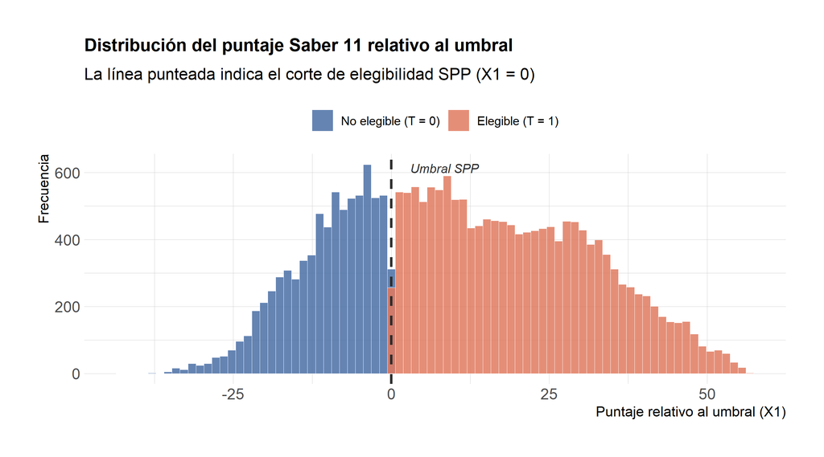

```r
ggplot(df, aes(x = X1, fill = factor(T))) +
  geom_histogram(bins = 80, color = "white", linewidth = 0.2, alpha = 0.85,
                 position = "identity") +
  geom_vline(xintercept = 0, color = COL_UMBR, linewidth = 0.9, linetype = "dashed") +
  annotate("text", x = 3, y = Inf, label = "Umbral SPP",
           vjust = 2, hjust = 0, size = 3.5, color = COL_UMBR, fontface = "italic") +
  scale_fill_manual(
    values = c("0" = COL_CTRL, "1" = COL_TRAT),
    labels = c("0" = "No elegible (T = 0)", "1" = "Elegible (T = 1)")
  ) +
  scale_x_continuous(labels = label_number()) +
  scale_y_continuous(labels = label_comma()) +
  labs(
    title    = "Distribución del puntaje Saber 11 relativo al umbral",
    subtitle = "La línea punteada indica el corte de elegibilidad SPP (X1 = 0)",
    x        = "Puntaje relativo al umbral (X1)",
    y        = "Frecuencia",
    fill     = NULL
  ) +
  theme(legend.position = "top")
```

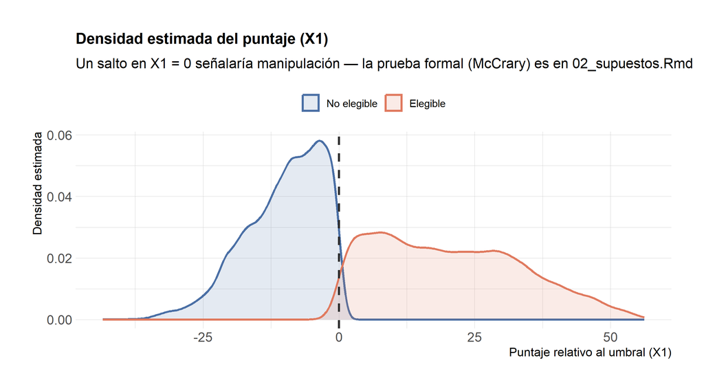

```r
ggplot(df, aes(x = X1, color = factor(T), fill = factor(T))) +
  geom_density(alpha = 0.15, linewidth = 0.9) +
  geom_vline(xintercept = 0, color = COL_UMBR, linewidth = 0.9, linetype = "dashed") +
  scale_color_manual(
    values = c("0" = COL_CTRL, "1" = COL_TRAT),
    labels = c("No elegible", "Elegible")
  ) +
  scale_fill_manual(
    values = c("0" = COL_CTRL, "1" = COL_TRAT),
    labels = c("No elegible", "Elegible")
  ) +
  labs(
    title    = "Densidad estimada del puntaje (X1)",
    subtitle = "Un salto en X1 = 0 señalaría manipulación — la prueba formal (McCrary) es en 02_supuestos.Rmd",
    x        = "Puntaje relativo al umbral (X1)",
    y        = "Densidad estimada",
    color    = NULL, fill = NULL
  ) +
  theme(legend.position = "top")
```

### Observaciones disponibles por ventana alrededor del umbral

En RDD solo importan las observaciones dentro del **ancho de banda** óptimo. Esta tabla muestra cuántos datos tenemos a cada distancia del umbral — el dato clave para anticipar la precisión del estimador.

```r
ventanas <- c(5, 10, 20, 30)

tibble(
  Ventana  = paste0("±", ventanas),
  `N total` = map_int(ventanas, ~ sum(abs(df$X1) <= .x)),
  `N izq.`  = map_int(ventanas, ~ sum(df$X1 >= -.x & df$X1 < 0)),
  `N der.`  = map_int(ventanas, ~ sum(df$X1 >= 0  & df$X1 <= .x)),
  `% del total` = map_chr(ventanas, ~ paste0(
    round(sum(abs(df$X1) <= .x) / nrow(df) * 100, 1), "%"
  ))
) %>%
  add_row(
    Ventana       = "Total",
    `N total`     = nrow(df),
    `N izq.`      = sum(df$X1 < 0),
    `N der.`      = sum(df$X1 >= 0),
    `% del total` = "100%"
  ) %>%
  kable(
    caption = "Observaciones disponibles por ventana alrededor del umbral (X1 = 0)",
    format.args = list(big.mark = ",")
  ) %>%
  kable_styling(bootstrap_options = c("striped", "hover", "condensed"),
                full_width = FALSE) %>%
  row_spec(nrow(ventanas) + 1, bold = TRUE)
```

Observaciones disponibles por ventana alrededor del umbral (X1 = 0)

| Ventana | N total | N izq. | N der. | % del total |
| --- | --- | --- | --- | --- |
| ±5 | 4,360 | 2,217 | 2,143 | 18.8% |
| ±10 | 8,611 | 4,298 | 4,313 | 37.2% |
| ±20 | 14,841 | 6,875 | 7,966 | 64.2% |
| ±30 | 19,004 | 7,622 | 11,382 | 82.2% |
| Total | 23,132 | 7,709 | 15,423 | 100% |

## 4. Tipos de cumplimiento: tabla T × D

Antes de cualquier estimación, debemos entender **qué tan fuzzy es el diseño**. La tabla cruzada de T (elegibilidad) y D (tratamiento real) revela la distribución de los cuatro tipos de cumplimiento en la muestra completa.

```r
td_counts <- df %>%
  count(T, D) %>%
  group_by(T) %>%
  mutate(
    prop_dentro_T = n / sum(n),
    tipo = case_when(
      T == 0 & D == 0 ~ "Never-takers (o compliers control)",
      T == 0 & D == 1 ~ "Always-takers",
      T == 1 & D == 0 ~ "Never-takers",
      T == 1 & D == 1 ~ "Compliers (o always-takers)"
    )
  )

# Tabla amplia para presentar
df %>%
  mutate(
    T_label = ifelse(T == 1, "Elegible (T = 1)", "No elegible (T = 0)"),
    D_label = ifelse(D == 1, "Inscrito en élite (D = 1)", "No inscrito (D = 0)")
  ) %>%
  count(T_label, D_label) %>%
  mutate(
    prop    = paste0(round(n / nrow(df) * 100, 1), "%"),
    celda   = paste0(format(n, big.mark = ","), "  (", prop, ")")
  ) %>%
  select(T_label, D_label, celda) %>%
  pivot_wider(names_from = D_label, values_from = celda) %>%
  rename(Elegibilidad = T_label) %>%
  kable(
    caption = "Tabla de cumplimiento T × D (frecuencias y % del total)"
  ) %>%
  kable_styling(bootstrap_options = c("striped", "hover"), full_width = FALSE) %>%
  add_header_above(c(" " = 1, "Tratamiento efectivo (D)" = 2))
```

Tabla de cumplimiento T × D (frecuencias y % del total)

| Elegibilidad | Tratamiento efectivo (D) Inscrito en élite (D = 1) | Tratamiento efectivo (D) No inscrito (D = 0) |
| --- | --- | --- |
| Elegible (T = 1) | 9,165 (39.6%) | 6,258 (27.1%) |
| No elegible (T = 0) | NA | 7,709 (33.3%) |

```r
# Salto en P(D=1) en el umbral — estimación naive de la fuerza del instrumento
p_D_elegible    <- mean(df$D[df$T == 1], na.rm = TRUE)
p_D_no_elegible <- mean(df$D[df$T == 0], na.rm = TRUE)
salto_D         <- p_D_elegible - p_D_no_elegible

cat(sprintf(
  "P(D=1 | T=1) = %.3f   |   P(D=1 | T=0) = %.3f   |   Salto = %.3f (%.1f pp)\n",
  p_D_elegible, p_D_no_elegible, salto_D, salto_D * 100
))
```

```
## P(D=1 | T=1) = 0.594   |   P(D=1 | T=0) = 0.000   |   Salto = 0.594 (59.4 pp)
```

> **Interpretación:** La diferencia P(D=1 | T=1) − P(D=1 | T=0) es la estimación naive del **salto en la primera etapa**. En un diseño *sharp* este salto sería 1.0 (todos los elegibles se inscriben). Un salto menor confirma el carácter *fuzzy* y determina la fuerza del instrumento — valores por debajo de 0.1 sugerirían un instrumento débil.

## 5. Primera etapa: toma del tratamiento (D vs. X1)

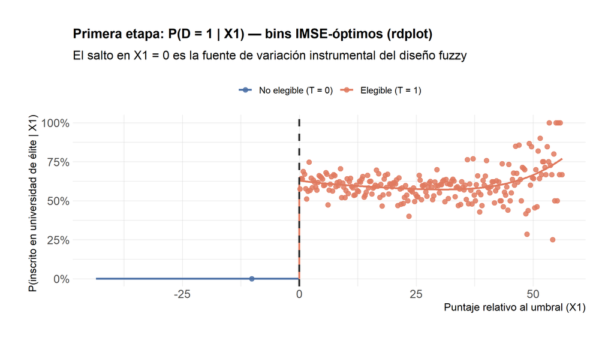

Visualización canónica RDD: primera etapa

```r
# Extraemos datos de rdplot para regraficar con nuestro tema
rp_D <- rdplot(y = df$D, x = df$X1, hide = TRUE, title = "")

bins_D <- rp_D$vars_bins
poly_D <- rp_D$vars_poly

ggplot() +
  geom_point(
    data  = bins_D,
    aes(x = rdplot_mean_x, y = rdplot_mean_y, color = rdplot_mean_x >= 0),
    size = 2.2, alpha = 0.85
  ) +
  geom_line(
    data = poly_D,
    aes(x = rdplot_x, y = rdplot_y,
        color = rdplot_x >= 0, group = rdplot_x >= 0),
    linewidth = 0.9
  ) +
  geom_vline(xintercept = 0, color = COL_UMBR, linewidth = 0.9, linetype = "dashed") +
  scale_color_manual(
    values = c("FALSE" = COL_CTRL, "TRUE" = COL_TRAT),
    labels = c("FALSE" = "No elegible (T = 0)", "TRUE" = "Elegible (T = 1)")
  ) +
  scale_y_continuous(labels = label_percent()) +
  labs(
    title    = "Primera etapa: P(D = 1 | X1) — bins IMSE-óptimos (rdplot)",
    subtitle = "El salto en X1 = 0 es la fuente de variación instrumental del diseño fuzzy",
    x        = "Puntaje relativo al umbral (X1)",
    y        = "P(inscrito en universidad de élite | X1)",
    color    = NULL
  ) +
  theme(legend.position = "top")
```

> **Qué buscamos:** Un salto grande y nítido en X1 = 0 confirma la **relevancia del instrumento** (condición necesaria para 2SLS). La magnitud del salto — el mismo número calculado en la sección anterior — aparece aquí de forma visual.

## 6. Forma reducida: resultado vs. variable forzosa (Y vs. X1)

La **forma reducida** es la relación entre superar el umbral (T) y el resultado final Y, sin pasar por D. Una discontinuidad aquí, combinada con el salto en D, es evidencia prima facie de un efecto causal del programa.

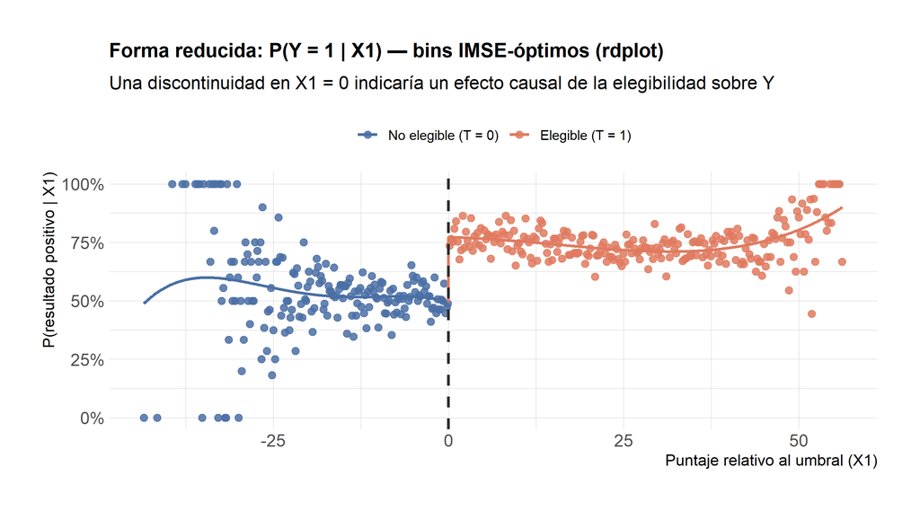

Visualización canónica RDD: forma reducida

```r
rp_Y <- rdplot(y = df$Y, x = df$X1, hide = TRUE, title = "")

bins_Y <- rp_Y$vars_bins
poly_Y <- rp_Y$vars_poly

ggplot() +
  geom_point(
    data  = bins_Y,
    aes(x = rdplot_mean_x, y = rdplot_mean_y, color = rdplot_mean_x >= 0),
    size = 2.2, alpha = 0.85
  ) +
  geom_line(
    data = poly_Y,
    aes(x = rdplot_x, y = rdplot_y,
        color = rdplot_x >= 0, group = rdplot_x >= 0),
    linewidth = 0.9
  ) +
  geom_vline(xintercept = 0, color = COL_UMBR, linewidth = 0.9, linetype = "dashed") +
  scale_color_manual(
    values = c("FALSE" = COL_CTRL, "TRUE" = COL_TRAT),
    labels = c("FALSE" = "No elegible (T = 0)", "TRUE" = "Elegible (T = 1)")
  ) +
  scale_y_continuous(labels = label_percent()) +
  labs(
    title    = "Forma reducida: P(Y = 1 | X1) — bins IMSE-óptimos (rdplot)",
    subtitle = "Una discontinuidad en X1 = 0 indicaría un efecto causal de la elegibilidad sobre Y",
    x        = "Puntaje relativo al umbral (X1)",
    y        = "P(resultado positivo | X1)",
    color    = NULL
  ) +
  theme(legend.position = "top")
```

> **Intuición Fuzzy RDD:**
> $$\widehat{\text{LATE}} = \frac{\text{salto en }
> \mathbb{E}[Y \mid X_1]}{\text{salto en } \mathbb{E}[D \mid X_1]}
> \bigg|_{X_1 = 0}$$
> El numerador es el salto visible en esta gráfica; el denominador es el salto de la sección anterior. El cociente es la estimación no paramétrica del LATE para los *compliers*.

## 7. Covariables demográficas

Exploramos la distribución de las covariables **pre-tratamiento** por grupo de elegibilidad. Estas variables son anteriores al examen, por lo que no deberían ser afectadas por el programa — sirven de chequeo de balance.

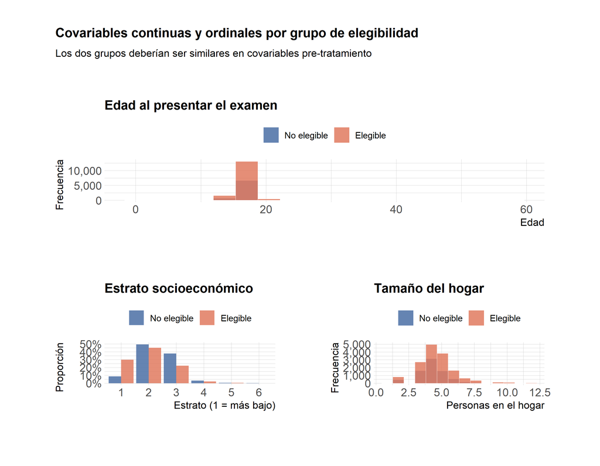

```r
p_edad <- ggplot(df, aes(x = icfes_age, fill = factor(T))) +
  geom_histogram(bins = 18, color = "white", linewidth = 0.2,
                 alpha = 0.85, position = "identity") +
  scale_fill_manual(
    values = c("0" = COL_CTRL, "1" = COL_TRAT),
    labels = c("No elegible", "Elegible")
  ) +
  scale_y_continuous(labels = label_comma()) +
  labs(title = "Edad al presentar el examen",
       x = "Edad", y = "Frecuencia", fill = NULL) +
  theme(legend.position = "top")

p_estrato <- df %>%
  filter(!is.na(icfes_stratum)) %>%
  count(icfes_stratum, T) %>%
  group_by(T) %>%
  mutate(prop = n / sum(n)) %>%
  ggplot(aes(x = factor(icfes_stratum), y = prop, fill = factor(T))) +
  geom_col(position = "dodge", alpha = 0.85) +
  scale_fill_manual(
    values = c("0" = COL_CTRL, "1" = COL_TRAT),
    labels = c("No elegible", "Elegible")
  ) +
  scale_y_continuous(labels = label_percent()) +
  labs(title = "Estrato socioeconómico",
       x = "Estrato (1 = más bajo)", y = "Proporción", fill = NULL) +
  theme(legend.position = "top")

p_famsize <- df %>%
  filter(!is.na(icfes_famsize)) %>%
  ggplot(aes(x = icfes_famsize, fill = factor(T))) +
  geom_histogram(bins = 14, color = "white", linewidth = 0.2,
                 alpha = 0.85, position = "identity") +
  scale_fill_manual(
    values = c("0" = COL_CTRL, "1" = COL_TRAT),
    labels = c("No elegible", "Elegible")
  ) +
  scale_y_continuous(labels = label_comma()) +
  labs(title = "Tamaño del hogar",
       x = "Personas en el hogar", y = "Frecuencia", fill = NULL) +
  theme(legend.position = "top")

p_edad / (p_estrato + p_famsize) +
  plot_annotation(
    title    = "Covariables continuas y ordinales por grupo de elegibilidad",
    subtitle = "Los dos grupos deberían ser similares en covariables pre-tratamiento",
    theme    = theme(
      plot.title    = element_text(size = 14, face = "bold"),
      plot.subtitle = element_text(size = 11)
    )
  )
```

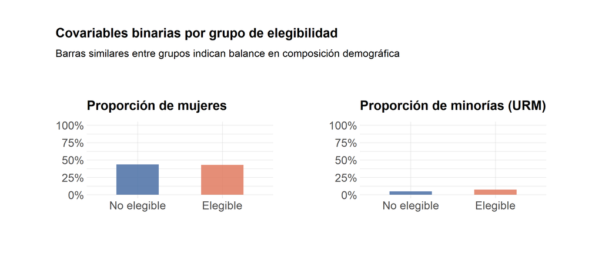

```r
p_female <- df %>%
  count(icfes_female, T) %>%
  group_by(T) %>%
  mutate(prop = n / sum(n)) %>%
  filter(icfes_female == 1) %>%
  ggplot(aes(x = factor(T), y = prop, fill = factor(T))) +
  geom_col(width = 0.5, alpha = 0.85) +
  scale_fill_manual(values = c("0" = COL_CTRL, "1" = COL_TRAT)) +
  scale_x_discrete(labels = c("No elegible", "Elegible")) +
  scale_y_continuous(labels = label_percent(), limits = c(0, 1)) +
  labs(title = "Proporción de mujeres", x = NULL, y = NULL) +
  theme(legend.position = "none")

p_urm <- df %>%
  count(icfes_urm, T) %>%
  group_by(T) %>%
  mutate(prop = n / sum(n)) %>%
  filter(icfes_urm == 1) %>%
  ggplot(aes(x = factor(T), y = prop, fill = factor(T))) +
  geom_col(width = 0.5, alpha = 0.85) +
  scale_fill_manual(values = c("0" = COL_CTRL, "1" = COL_TRAT)) +
  scale_x_discrete(labels = c("No elegible", "Elegible")) +
  scale_y_continuous(labels = label_percent(), limits = c(0, 1)) +
  labs(title = "Proporción de minorías (URM)", x = NULL, y = NULL) +
  theme(legend.position = "none")

(p_female + p_urm) +
  plot_annotation(
    title    = "Covariables binarias por grupo de elegibilidad",
    subtitle = "Barras similares entre grupos indican balance en composición demográfica",
    theme    = theme(
      plot.title    = element_text(size = 14, face = "bold"),
      plot.subtitle = element_text(size = 11)
    )
  )
```

### Resultado Y por subgrupos demográficos

Antes de estimar efectos heterogéneos, exploramos cómo varía el resultado Y en la muestra completa según género, estatus de minoría y estrato. Esto motiva el análisis CATE de `04_cate.Rmd`.

```r
# Por género y URM
df %>%
  mutate(
    Género = ifelse(icfes_female == 1, "Mujer", "Hombre"),
    URM    = ifelse(icfes_urm == 1, "Minoría (URM)", "No minoría")
  ) %>%
  group_by(Género, URM) %>%
  summarise(
    n          = n(),
    `Y medio (%)` = round(mean(Y, na.rm = TRUE) * 100, 1),
    `D medio (%)` = round(mean(D, na.rm = TRUE) * 100, 1),
    .groups = "drop"
  ) %>%
  kable(caption = "Resultado Y promedio por género y estatus de minoría") %>%
  kable_styling(bootstrap_options = c("striped", "hover", "condensed"),
                full_width = FALSE)
```

Resultado Y promedio por género y estatus de minoría

| Género | URM | n | Y medio (%) | D medio (%) |
| --- | --- | --- | --- | --- |
| Hombre | Minoría (URM) | 898 | 68.8 | 45.9 |
| Hombre | No minoría | 12254 | 67.1 | 39.1 |
| Mujer | Minoría (URM) | 659 | 69.2 | 47.5 |
| Mujer | No minoría | 9321 | 65.7 | 39.2 |

```r
df %>%
  filter(!is.na(icfes_stratum)) %>%
  group_by(Estrato = factor(icfes_stratum)) %>%
  summarise(
    n             = n(),
    `Y medio (%)` = round(mean(Y, na.rm = TRUE) * 100, 1),
    `D medio (%)` = round(mean(D, na.rm = TRUE) * 100, 1),
    `T medio (%)` = round(mean(T, na.rm = TRUE) * 100, 1),
    .groups = "drop"
  ) %>%
  kable(caption = "Resultado Y promedio por estrato socioeconómico") %>%
  kable_styling(bootstrap_options = c("striped", "hover", "condensed"),
                full_width = FALSE)
```

Resultado Y promedio por estrato socioeconómico

| Estrato | n | Y medio (%) | D medio (%) | T medio (%) |
| --- | --- | --- | --- | --- |
| 1 | 5265 | 68.1 | 49.6 | 87.3 |
| 2 | 10742 | 65.9 | 38.9 | 64.7 |
| 3 | 6315 | 66.8 | 33.1 | 53.9 |
| 4 | 612 | 68.6 | 34.8 | 58.3 |
| 5 | 116 | 61.2 | 31.9 | 58.6 |
| 6 | 23 | 56.5 | 26.1 | 52.2 |

> **Qué buscamos:** Si Y varía mucho entre subgrupos, hay heterogeneidad que vale la pena explorar en el análisis CATE. Si Y es similar en todos los grupos, el efecto promedio puede ser representativo.

## 8. Balance de covariables alrededor del umbral

Un supuesto central del diseño RD es que **no hay discontinuidad en las covariables pre-tratamiento** en X1 = 0. Aquí hacemos la exploración visual; la prueba formal (con intervalos de confianza) está en `02_supuestos.Rmd`.

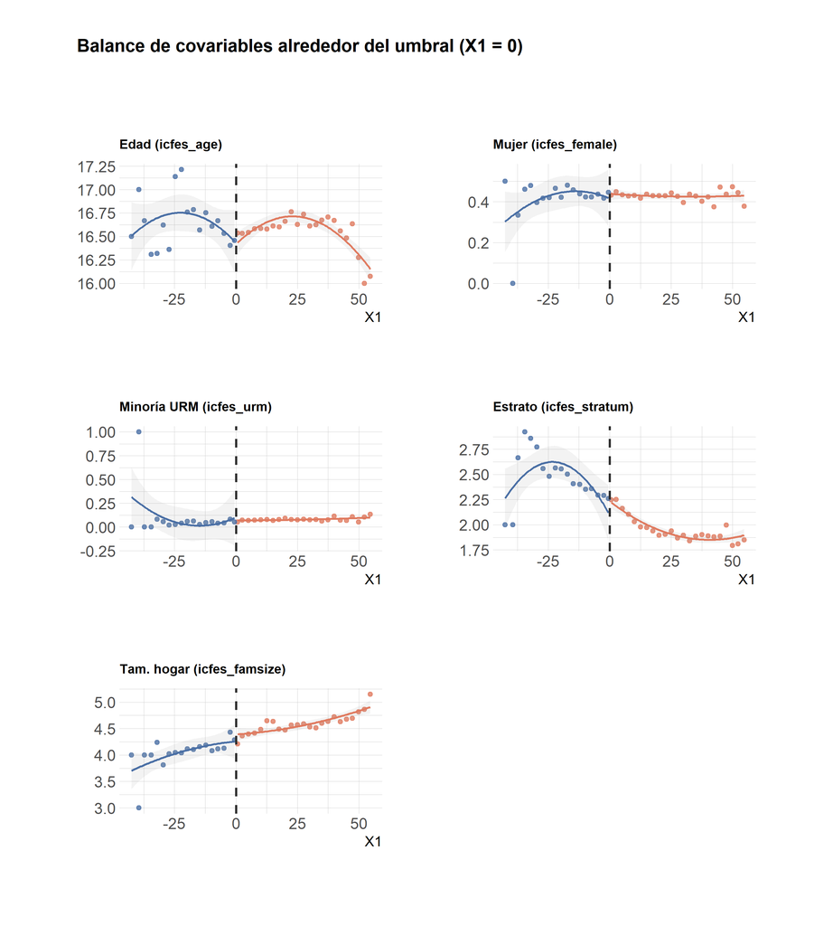

```r
cov_lista <- list(
  "Edad (icfes_age)"            = "icfes_age",
  "Mujer (icfes_female)"        = "icfes_female",
  "Minoría URM (icfes_urm)"     = "icfes_urm",
  "Estrato (icfes_stratum)"     = "icfes_stratum",
  "Tam. hogar (icfes_famsize)"  = "icfes_famsize"
)

plots_balance <- lapply(names(cov_lista), function(label) {
  var <- cov_lista[[label]]

  df_b <- df %>%
    filter(!is.na(.data[[var]])) %>%
    mutate(
      lado = ifelse(X1 >= 0, "Elegible", "No elegible"),
      bin  = cut(X1, breaks = 40)
    ) %>%
    group_by(bin, lado) %>%
    summarise(
      mean_cov = mean(.data[[var]]),
      mean_X1  = mean(X1),
      .groups  = "drop"
    )

  ggplot(df_b, aes(x = mean_X1, y = mean_cov, color = lado)) +
    geom_point(size = 1.5, alpha = 0.8) +
    geom_smooth(method = "lm", formula = y ~ poly(x, 2), se = TRUE,
                alpha = 0.12, linewidth = 0.7) +
    geom_vline(xintercept = 0, color = COL_UMBR,
               linewidth = 0.8, linetype = "dashed") +
    scale_color_manual(
      values = c("No elegible" = COL_CTRL, "Elegible" = COL_TRAT)
    ) +
    labs(title = label, x = "X1", y = NULL, color = NULL) +
    theme(
      legend.position = "none",
      plot.title      = element_text(size = 10, face = "bold")
    )
})

wrap_plots(plots_balance, ncol = 2) +
  plot_annotation(
    title    = "Balance de covariables alrededor del umbral (X1 = 0)",
    subtitle = "Sin discontinuidades visibles → supuesto de continuidad preliminarmente soportado",
    theme    = theme(
      plot.title    = element_text(size = 14, face = "bold"),
      plot.subtitle = element_text(size = 11)
    )
  )
```

> **Lectura esperada:** Si el diseño es válido, las líneas de regresión a ambos lados del umbral deberían coincidir en X1 = 0. Un quiebre abrupto en cualquier covariable sería evidencia de manipulación o contaminación del diseño.

## Resumen y próximos pasos

```r
# Calculamos los hallazgos del dataset real — no texto fijo
salto_D_val <- mean(df$D[df$T == 1], na.rm = TRUE) - mean(df$D[df$T == 0], na.rm = TRUE)
salto_Y_val <- mean(df$Y[df$T == 1], na.rm = TRUE) - mean(df$Y[df$T == 0], na.rm = TRUE)
n_faltantes <- sum(is.na(df$icfes_stratum)) + sum(is.na(df$icfes_famsize))
n_ventana10 <- sum(abs(df$X1) <= 10)

tibble(
  Sección = c(
    "Datos",
    "Variable forzosa",
    "Cumplimiento T × D",
    "Primera etapa",
    "Forma reducida",
    "Balance de covariables"
  ),
  `Hallazgo` = c(
    paste0(format(nrow(df), big.mark = ","),
           " obs. · 9 variables · ",
           format(n_faltantes, big.mark = ","),
           " valores faltantes (estrato y tam. hogar)"),
    paste0("Distribución visualmente continua en X1 = 0 · ",
           format(n_ventana10, big.mark = ","),
           " obs. dentro de ±10 puntos del umbral"),
    paste0("Salto en P(D=1): +",
           round(salto_D_val * 100, 1),
           " pp al cruzar el umbral → diseño fuzzy confirmado"),
    paste0("P(D=1 | T=1) = ",
           round(mean(df$D[df$T == 1], na.rm = TRUE), 3),
           " vs P(D=1 | T=0) = ",
           round(mean(df$D[df$T == 0], na.rm = TRUE), 3),
           " → instrumento relevante"),
    paste0("Salto en P(Y=1): +",
           round(salto_Y_val * 100, 1),
           " pp al cruzar el umbral → evidencia prima facie de efecto causal"),
    "Sin saltos visibles en ninguna covariable pre-tratamiento (verificación formal pendiente)"
  )
) %>%
  kable(caption = "Hallazgos del análisis exploratorio — calculados del dataset") %>%
  kable_styling(
    bootstrap_options = c("striped", "hover"),
    full_width = TRUE
  ) %>%
  column_spec(1, bold = TRUE, width = "20%") %>%
  column_spec(2, width = "80%")
```

Hallazgos del análisis exploratorio — calculados del dataset

[output not shown]

**Siguientes pasos — `02_supuestos.Rmd`:**

1. Prueba formal de McCrary con `rddensity` — continuidad de la densidad de X1 en el umbral
2. Tabla de balance con pruebas t por covariable en la vecindad del umbral
3. Verificación de ausencia de efectos en umbrales **placebo** (X1 = −10, X1 = +10)
4. Selección del ancho de banda óptimo con `rdbwselect`